# Association of natural disaster and covid experiences with the number of depression symptoms, accounting for genetic risk of depression

Jodi T Thomas

02 September, 2026

# Load Packages

```r
library(haven)        # for importing SPSS files
library(labelled)     # for looking at metadata stored as variable labels
library(readxl)       # read in excel files
library(EnvStats)     # for sample size on ggplot2 plots
library(glmmTMB)      # to fit GLMMs, and to allow dispersion parameter to vary with chosen explanatory variables
library(VGAM)         # to fit ordinal regression models
library(MuMIn)        # to calculate AICc
library(MASS)         # for negative binomial and proportional odds models
library(performance)  # for model diagnostics
library(see)          # needed for performance model diagnostics
library(ggfortify)    # needed for autoplot model diagnostics
library(DHARMa)       # for residuals and model diagnostics
library(generalhoslem)# for model diagnostics for proportional odds model in polr
library(brant)        # for model diagnostics for proportional odds model in polr
library(gofcat)       # for model diagnostic for models in VGAM
library(effects)      # for nice summary of model results (allEffects)
library(sjPlot)       # for summary plot of model results
library(ggplotify)    # to use patchwork on lattice plots (created by allEffects)
library(broom.mixed)  # for tidy output
library(emmeans)      # for estimating marginal means
library(patchwork)    # for putting together plots into a figure
library(ggeffects)    # create tidy data frames from marginal data
library(knitr)        # for kable tables
library(ggvenn)       # for venn diagram
library(ggforce)      # ggplot circles
library(Hmisc)        # power analyses
library(knitr)        # for kable tables
library(tidyverse)
```

# Set up Phenotype Data

## Read in the phenotype data

- All 4 surveys - data already cleaned in ~/Working/AGDS/R/data
- Use key to match participants across surveys
- Date of birth data for each participant in covid waves 1 and 2 (to calculate age) from
  - /path_two/AGDS_FollowUp_COVID/2021Survey/AGDS_covidwave1_dateofbirth.csv
  - /path_two/AGDS_FollowUp_COVID/Penelope 070722/Richard/AGDS_covidwave2_dateofbirth.csv

```r
# Read in tidied AGDS data
load(file = "/path_one/AGDS/R/data/AGDS_data.RData")

# Read in tidied AGDS follow-up data
load(file = "/path_one/AGDS/R/data/AGDS_followup_data.RData")

# Read in tidied AGDS covid wave 1 data
load(file = "/path_one/AGDS/R/data/AGDS_COVIDwave1_data.RData")

# Read in tidied AGDS covid wave 2 data
load(file = "/path_one/AGDS/R/data/AGDS_COVIDwave2_data.RData")


# Date of birth data for each participant in covid waves 1 and 2 (to calculate age)
DOB_COVIDwave1 <- read_delim(file = "data/AGDS_covidwave1_dateofbirth.csv")
DOB_COVIDwave2 <- read_delim(file = "data/AGDS_covidwave2_dateofbirth.csv")

# Read in key to match aprticipants across surveys
id_map <- read_csv(file = "/path_one/AGDS/R/data_combine_datasets/AGDS_studycode_key.csv")

# Read in list of withdrawals
withdrawals <- read_excel("/path_one/AGDS/R/data_combine_datasets/AGDS_Withdrawals_03102024.xlsx")
```

## Tidy and combine datasets

```r
# Use id_map to get a standardised ID for each participant which can then be used to merge all datasets

# Step 1: Join each dataset with id_map to get the standardised ID (column FINALID)
AGDS_baseline_std <- AGDS_data %>%
  rename(STUDYCODE = STUDYID) %>%           # baseline uses STUDYID
  left_join(id_map, by = "STUDYCODE") %>%
  mutate(FINALID = coalesce(FINALID, STUDYCODE))   # if FINALID is missing, use the original ID (i.e. this participant is not in the id_map)

AGDS_followup_std <- AGDS_followup_data %>%
  select(-STUDYCODE) %>%                    # STUDYCODE col in follow-up is empty
  rename(STUDYCODE = StudyCode.0) %>%       # follow-up uses StudyCode.0
  left_join(id_map, by = "STUDYCODE") %>%
  mutate(FINALID = coalesce(FINALID, STUDYCODE))   # if FINALID is missing, use the original ID (i.e. this participant is not in the id_map)

AGDS_covid1_std <- AGDS_COVIDwave1_data %>%
  select(-STUDYCODE) %>%                    # STUDYCODE col in covid1 is empty
  rename(STUDYCODE = STUDYCODE_ID) %>%      # covid1 uses STUDYCODE_ID
  left_join(id_map, by = "STUDYCODE") %>%
  mutate(FINALID = coalesce(FINALID, STUDYCODE))   # if FINALID is missing, use the original ID (i.e. this participant is not in the id_map)

AGDS_covid2_std <- AGDS_COVIDwave2_data %>%
  rename(STUDYCODE = StudyCode) %>%         # covid2 uses StudyCode
  left_join(id_map, by = "STUDYCODE") %>%
  mutate(FINALID = coalesce(FINALID, STUDYCODE))   # if FINALID is missing, use the original ID (i.e. this participant is not in the id_map)

AGDS_covid1_dob_std <- DOB_COVIDwave1 %>%
  rename(STUDYCODE = STUDYCODE_ID) %>%      # dob file uses STUDYCODE_ID
  left_join(id_map, by = "STUDYCODE") %>%
  mutate(FINALID = coalesce(FINALID, STUDYCODE))   # if FINALID is missing, use the original ID (i.e. this participant is not in the id_map)

AGDS_covid2_dob_std <- DOB_COVIDwave2 %>%
  rename(STUDYCODE = STUDYCODE_ID) %>%      # dob file uses STUDYCODE_ID
  left_join(id_map, by = "STUDYCODE") %>%
  mutate(FINALID = coalesce(FINALID, STUDYCODE))   # if FINALID is missing, use the original ID (i.e. this participant is not in the id_map)

# Step 2: Now that all participants use the same standardised IDs (FINALID), join all datasets

# Put all standardised datasets into a named list
datasets <- list(
  baseline   = AGDS_baseline_std,
  followup   = AGDS_followup_std,
  covid1     = AGDS_covid1_std,
  covid2     = AGDS_covid2_std,
  covid1dob  = AGDS_covid1_dob_std,
  covid2dob  = AGDS_covid2_dob_std
)

# Clean and add suffix to columns for each dataset (so can determine which dataset each column originated from)
datasets_cleaned <- imap(datasets, function(df, dataset_name) {
  df %>%
    select(-STUDYCODE) %>%  # drop old studycode if present
    rename_with(~ paste0(.x, "_", dataset_name), -FINALID)  # add suffix to all columns except FINALID
})

# Merge all datasets by FINALID
AGDS_all <- reduce(datasets_cleaned, full_join, by = "FINALID") %>%
  select(FINALID, everything())

# Remove individuals that have asked to be withdrawn
withdrawals_std <- withdrawals %>%
  rename(STUDYCODE = STUDYCODE_ID) %>%      # withdrawals file uses STUDYCODE_ID
  left_join(id_map, by = "STUDYCODE") %>%
  mutate(FINALID = coalesce(FINALID, STUDYCODE))   # if FINALID is missing, use the original ID (i.e. this participant is not in the id_map)

AGDS_all <- AGDS_all %>%
  anti_join(withdrawals_std, by = join_by(FINALID))

# Remove labels from data frame (models can't handle them still being there)
# user_na_to_na = TRUE to convert user defined missing values to NA - don't think I need this but include just to be safe
phen_data <- remove_labels(AGDS_all, user_na_to_na = TRUE)

save(phen_data, file = "data/phen_data.RData")
```

## Create new phenotypes

- Create new phenotypes with all surveys now joined in to one dataframe

```r
# Create new phenotypes with all surveys now joined in to one dataframe

## AGE ##
# Using dob in covid 1 and 2
phen_data <- phen_data %>%
  mutate(StartDate_covid1 = as.Date(StartDate_covid1),
         AGE_covid1 = floor(as.numeric(StartDate_covid1 - dmy(dateofbirth_covid1dob))/365.25),
         StartDate_covid2 = as.Date(StartDate_covid2),
         AGE_covid2 = floor(as.numeric(StartDate_covid2 - dmy(dateofbirth_covid2dob))/365.25))


## AGDS BASELINE NATURAL DISASTERS ##

# Create new columns for defining natural disaster exposure in relation to timing of depression
# NDEXPOS_DEPRWAFTER = yes (experienced a ND but only if worst depression occurred after the first ND experience.) No (never experienced ND)
# NDEXPOSME_DEPRWAFTER = as above but restricted to ND exposure happened to me
# NDEXPOS_DEPRFAFTER = yes (experienced a ND but only if first depression occurred after the first ND experience.) No (never experienced ND)
# NDEXPOSME_DEPRFAFTER = as above but restricted to ND exposure happened to me

phen_data <- phen_data %>%
  mutate(NDEXPOS_DEPRWAFTER = case_when(
    NDEXPOS_baseline == "Yes" & NDFDEPRW_baseline == "after" ~ "Yes",
    NDEXPOS_baseline == "No" ~ "No"
  ),
  NDEXPOS_DEPRWAFTER = factor(NDEXPOS_DEPRWAFTER, levels = c('No', "Yes")),

  NDEXPOSME_DEPRWAFTER = case_when(
    NDEXPOSME_baseline == "Yes" & NDFDEPRW_baseline == "after" ~ "Yes",
    NDEXPOSME_baseline == "No" ~ "No"
  ),
  NDEXPOSME_DEPRWAFTER = factor(NDEXPOSME_DEPRWAFTER, levels = c('No', "Yes")),

  NDEXPOS_DEPRFAFTER = case_when(
    NDEXPOS_baseline == "Yes" & NDFDEPRF_baseline == "after" ~ "Yes",
    NDEXPOS_baseline == "No" ~ "No"
  ),
  NDEXPOS_DEPRFAFTER = factor(NDEXPOS_DEPRFAFTER, levels = c('No', "Yes")),

  NDEXPOSME_DEPRFAFTER = case_when(
    NDEXPOSME_baseline == "Yes" & NDFDEPRF_baseline == "after" ~ "Yes",
    NDEXPOSME_baseline == "No" ~ "No"
  ),
  NDEXPOSME_DEPRFAFTER = factor(NDEXPOSME_DEPRFAFTER, levels = c('No', "Yes")))

## COVID WAVE 1 AND WAVE 2 COVID EXPERIENCES ##
# COVIDALLBIN = Experienced any frightening, horrible or traumatic experiences related to COVID-19.
#   Yes = happened to me, witnessed it, learned about it or part of my job
#   No = No
# COVIDMEBIN = Experienced any frightening, horrible or traumatic experiences related to COVID-19.
#   Yes = happened to me
#   No = No, witnessed it, learned about it or part of my job
# If answered yes in wave 1 and/or 2 = yes
# If answered no in wave 1 and wave 2 = no
# Use NUMSYMPALL from wave 2 for all

phen_data <- phen_data %>%
  mutate(COVIDALLBIN_C1C2 = case_when(
    COVIDALLBIN_covid1==1 | COVIDALLBIN_covid2==1 ~ 1,
    COVIDALLBIN_covid1==0 & COVIDALLBIN_covid2==0 ~ 0
  ),
  COVIDALLBIN_C1C2 = factor(COVIDALLBIN_C1C2, levels = c('0', '1')),
  COVIDMEBIN_C1C2 = case_when(
    COVIDMEBIN_covid1==1 | COVIDMEBIN_covid2==1 ~ 1,
    COVIDMEBIN_covid1==0 & COVIDMEBIN_covid2==0 ~ 0
  ),
  COVIDMEBIN_C1C2 = factor(COVIDMEBIN_C1C2, levels = c('0', '1')))

## BUSHFIRE/FLODD FROM FOLLOW-UP AND COVID WAVE 1 AND COVID WAVE 2 ##
# BUSHFLOODHORR = whether participant experienced any frightening, horrible or traumatic experiences related to the bushfires and flooding over the past year (binary)
# Create new variable combining bushfire/flood and covid experiences
# Bushfire/flood and COVID = yes to bushfires/floods AND covid wave 1 and/or wave 2
# COVID only = yes to covid wave 1 and/or 2 and not to bushfire/flood
# Bushfire/flood only = yes to bushfire/flood and no to covid wave 1 and 2
# No = no to bushfires/floods and covid wave 1 and covid wave 2

phen_data <- phen_data %>%
  mutate(COVIDALL_BUSHFLOOD = case_when(
    COVIDALLBIN_C1C2==1 & BUSHFLOODHORR_followup==1 ~ "Bushfire/flood and COVID",
    COVIDALLBIN_C1C2==1 & BUSHFLOODHORR_followup==0 ~ "COVID only",
    COVIDALLBIN_C1C2==0 & BUSHFLOODHORR_followup==1 ~ "Bushfire/flood only",
    COVIDALLBIN_C1C2==0 & BUSHFLOODHORR_followup==0 ~ "No"
  ),
  COVIDALL_BUSHFLOOD = factor(COVIDALL_BUSHFLOOD, levels = c('No', 'Bushfire/flood only', 'COVID only', 'Bushfire/flood and COVID')),
  COVIDME_BUSHFLOOD = case_when(
    COVIDMEBIN_C1C2==1 & BUSHFLOODHORR_followup==1 ~ "Bushfire/flood and COVID",
    COVIDMEBIN_C1C2==1 & BUSHFLOODHORR_followup==0 ~ "COVID only",
    COVIDMEBIN_C1C2==0 & BUSHFLOODHORR_followup==1 ~ "Bushfire/flood only",
    COVIDMEBIN_C1C2==0 & BUSHFLOODHORR_followup==0 ~ "No"
  ),
  COVIDME_BUSHFLOOD = factor(COVIDME_BUSHFLOOD, levels = c('No', 'Bushfire/flood only', 'COVID only', 'Bushfire/flood and COVID')),
  COVIDALL_BUSHFLOOD_both = case_when(
    COVIDALL_BUSHFLOOD == "No" ~ "No",
    COVIDALL_BUSHFLOOD == "Bushfire/flood and COVID" ~ "Yes"
  ),
  COVIDALL_BUSHFLOOD_both = factor(COVIDALL_BUSHFLOOD_both, levels = c("No", "Yes")),
  COVIDME_BUSHFLOOD_both = case_when(
    COVIDME_BUSHFLOOD == "No" ~ "No",
    COVIDME_BUSHFLOOD == "Bushfire/flood and COVID" ~ "Yes"
  ),
  COVIDME_BUSHFLOOD_both = factor(COVIDME_BUSHFLOOD_both, levels = c("No", "Yes"))
  )



save(phen_data, file = "data/phen_data.RData")
```

# Remapper

## Save IDs to run in remapper

```r
# make list of AGDS IDs to calculate relatedness and PRS

# Save AGDS IDs
# One of the IDs has a bracket at the end "MDD12843)". There is another ID "MDD12843" so removed "MDD12843)"
AGDS_phenotype_IDs <- phen_data %>%
  select(FINALID) %>%
  rename(QID = FINALID) %>%
  filter(QID != "MDD12843)")

# save data for remapper
write.table(AGDS_phenotype_IDs, "data/AGDS_all4surveys_phenotype_IDs.txt", sep = "\t", row.names = FALSE, quote = FALSE)
# Then run through remapper for FID and IID
```

## Run remapper

- Restricts to only participants for who we have genotype data for
- And adds FID and IID and genetic sex

```
/path_three/Release11_Observed/GWAS_ID_remapper -headerline -intabdelim -dropancestryoutliers -removeduplicates -numericids=MDD -useQSKIN=NO -subset=Full_Observed -repeatoriginalid -outpedigree /path_one/AGDS/Natural_disasters_AGDS/R/data/AGDS_all4surveys_phenotype_IDs.txt > /path_one/AGDS/Natural_disasters_AGDS/R/data/AGDS_all4surveys_phenotype_IDs_remapper.txt
```

## Add 10 PCs

- PCs have already been made for all QIMR genotype data.
- Add 10 PCs and add as columns to file - to be used to account for ancestry differences.
- Match on column 2 (IID) in our remapper file and extracting columns 6-15 (PC1-10) from the principal component scores file, then printing these at the end of our remapper file = from column 11 as we have 10 columns already.

```
awk 'NR==FNR{A[$2]=$6 FS $7 FS $8 FS $9 FS $10 FS $11 FS $12 FS $13 FS $14 FS $15; next}(FNR==1){print $0, "PC1","PC2","PC3","PC4","PC5","PC6","PC7","PC8","PC9","PC10"; next} {$11=A[$2]}1' /path_three/Release11_Observed/AncestryChecks/GWAS_PrincipalComponentsScores.txt /path_one/AGDS/Natural_disasters_AGDS/R/data/AGDS_all4surveys_phenotype_IDs_remapper.txt > /path_one/AGDS/Natural_disasters_AGDS/R/data/AGDS_all4surveys_phenotype_IDs_remapper_PCs.txt
```

# Relatedness

- Input list of FID IID to plink to calculate relatedness of individuals

## Save list of IDs

- Save list of AGDS IDs with which to calculate relatedness

```
awk '{print $1,$2}' /path_one/AGDS/Natural_disasters_AGDS/R/data/AGDS_all4surveys_phenotype_IDs_remapper.txt > AGDS_IDs.txt
```

## Calculate pihat in PLINK

- Used script /path_one/Reference/Relatedness/01_AGDS_relatedness.sh

```
module load plink/1.90b7.4
plink --bfile /path_three/Release11_Observed/PLINK_format/GWAS_Build37PlusStrand \
 --chr 1-22 \
 --extract /path_one/Reference/GWAS_reference/R11_observed_genotypes_GSAchip_autosomes/Observed_genotypes_GSAchip_autosomes_MAF0.01_Geno0.02_Mind0.02_HWE0.0000000001_LD0.2.prune.in \
 --keep /path_one/AGDS/Natural_disasters_AGDS/R/data/AGDS_IDs.txt \
 --genome \
 --out AGDS_relatedness \
 --threads 2 \
 --min 0.1
```

## View distribution of relatedness

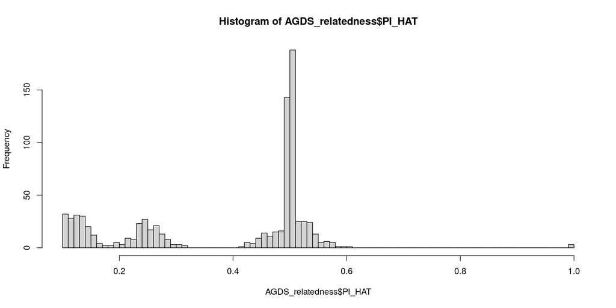

```r
hist(AGDS_relatedness$PI_HAT, breaks = 100)
```

```r
# Number with pihat > 0.25 (2nd degree relatedness)
AGDS_relatedness %>%
  filter(PI_HAT > 0.25) %>%
  summarise(n = n()) %>%
  kable(caption = "No. participants with relatedness pihat > 0.25 (2nd degree)")
```

No. participants with relatedness pihat > 0.25 (2nd degree)

| n |
| --- |
| 582 |

```r
# Number with pihat > 0.20 (2nd degree relatedness but with lower cut-off to account for variability)
AGDS_relatedness %>%
  filter(PI_HAT > 0.20) %>%
  summarise(n = n()) %>%
  kable(caption = "No. participants with relatedness pihat > 0.20 (2nd degree with lower cut-off to account for variability)")
```

No. participants with relatedness pihat > 0.20 (2nd degree with lower cut-off to account for variability)

| n |
| --- |
| 652 |

```r
# Number with pihat > 0.125 (3rd degree relatedness)
AGDS_relatedness %>%
  filter(PI_HAT > 0.125) %>%
  summarise(n = n()) %>%
  kable(caption = "No. participants with relatedness pihat > 0.125 (3rd degree)")
```

No. participants with relatedness pihat > 0.125 (3rd degree)

| n |
| --- |
| 745 |

```r
# Number with pihat > 0.10 (3rd degree relatedness but with lower cut-off to account for variability)
AGDS_relatedness %>%
  filter(PI_HAT > 0.10) %>%
  summarise(n = n()) %>%
  kable(caption = "No. participants with relatedness pihat > 0.10 (3rd degree with lower cut-off to account for variability)")
```

No. participants with relatedness pihat > 0.10 (3rd degree with lower cut-off to account for variability)

| n |
| --- |
| 818 |

```r
# Some individuals are paired with a 2nd participant more than once
AGDS_relatedness %>%
  group_by(IID1) %>%
  summarise(num_rows = n()) %>%
  filter(num_rows > 1) %>%
  summarise(num_individuals = n()) %>%
  kable(caption = "No. of participants in IID1 that are in more than one pairing")
```

No. of participants in IID1 that are in more than one pairing

| num_individuals |
| --- |
| 63 |

```r
AGDS_relatedness %>%
  group_by(IID2) %>%
  summarise(num_rows = n()) %>%
  filter(num_rows > 1) %>%
  summarise(num_individuals = n()) %>%
  kable(caption = "No. of participants in IID2 that are in more than one pairing")
```

No. of participants in IID2 that are in more than one pairing

| num_individuals |
| --- |
| 58 |

# Add Genetic data

## Add genetic sex and 10 PCs to phenotype data

```r
# Format genetic sex and PCs data
AGDS_sex_PCs <- AGDS_sex_PCs %>%
  mutate(SEX = case_when(
    SEX == 1 ~ "Male",
    SEX == 2 ~ "Female"
  ),
  SEX = factor(SEX, levels = c("Male", "Female"))) %>%
  rename(FINALID = SUPPLIED_ID) %>%
  select(FINALID, SEX, contains("PC"), IID) %>%
  rename_with(~ paste(., "genetic", sep = "_"), -FINALID)

# Format PRS data
AGDS_PRS <- AGDS_PRS %>%
  rename(IID_genetic = IID,
         PRS_genetic = SCORESUM) %>%
  select(IID_genetic, PRS_genetic)

# Merge genetic sex + PCs data with PRS data
AGDS_sex_PCs_PRS <- AGDS_sex_PCs %>%
  left_join(AGDS_PRS)

# Merge genetic data (sex, PCs, PRS) with phenotype data (all 4 surveys combined)
phen_gen_PRS_data <- AGDS_sex_PCs_PRS %>%
  full_join(phen_data)


save(phen_gen_PRS_data, file = "data/phen_gen_PRS_data.RData")
```

## Remove related individuals

```r
AGDS_remove_related_list <- AGDS_relatedness %>%
  filter(PI_HAT > 0.2) %>%
  select(IID1) %>%
  distinct()
save(AGDS_remove_related_list, file = "data/AGDS_remove_related_list.RData")

# Combine phen_gen_PRS_data and remove_list so new dataset doesn't include IIDs in remove_list
phen_gen_PRS_data_relatedremoved <- phen_gen_PRS_data %>%
  anti_join(AGDS_remove_related_list, by = c('IID_genetic' = "IID1"))


save(phen_gen_PRS_data_relatedremoved, file = "data/phen_gen_PRS_data_relatedremoved.RData")
```

# Check PRS

- Check PRS values distribution and check correlation between depression PRS and depression phenotypes - should be high

## Standardise PRS

```r
# standardise PRS values within data using
df_ND_covid <- phen_gen_PRS_data_relatedremoved %>%
  mutate(PRS_stand_genetic = scale(PRS_genetic, center = TRUE, scale = TRUE))

save(df_ND_covid, file = "data/df_ND_covid.RData")
```

## PRS Distribution

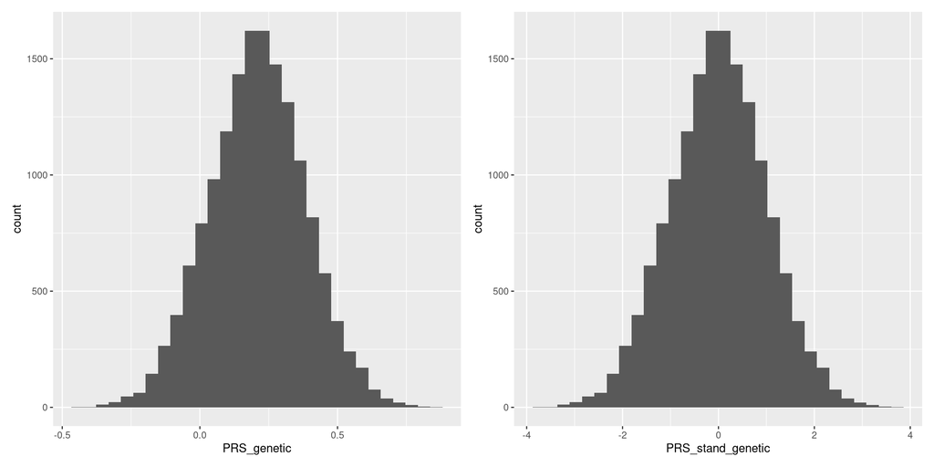

```r
a <- ggplot(df_ND_covid, aes(x = PRS_genetic)) +
  geom_histogram()

b <- ggplot(df_ND_covid, aes(x = PRS_stand_genetic)) +
  geom_histogram()

a + b
```

```r
df_ND_covid %>%
  summarise(mean_PRS = mean(PRS_genetic, na.rm = TRUE),
            mean_PRS_standardised = mean(PRS_stand_genetic, na.rm = TRUE),
            sd_PRS = sd(PRS_genetic, na.rm = TRUE),
            sd_PRS_standardised = sd(PRS_stand_genetic, na.rm = TRUE)) %>%
  kable()
```

| mean_PRS | mean_PRS_standardised | sd_PRS | sd_PRS_standardised |
| --- | --- | --- | --- |
| 0.2088566 | 0 | 0.1741741 | 1 |

```r
df_ND_covid %>%
  group_by(SEX_genetic) %>%
  drop_na(SEX_genetic) %>%
  summarise(mean_PRS = mean(PRS_genetic, na.rm = TRUE),
            mean_PRS_standardised = mean(PRS_stand_genetic, na.rm = TRUE),
            sd_PRS = sd(PRS_genetic, na.rm = TRUE),
            sd_PRS_standardised = sd(PRS_stand_genetic, na.rm = TRUE)) %>%
  kable()
```

| SEX_genetic | mean_PRS | mean_PRS_standardised | sd_PRS | sd_PRS_standardised |
| --- | --- | --- | --- | --- |
| Male | 0.2117936 | 0.0168623 | 0.1739187 | 0.9985335 |
| Female | 0.2079751 | -0.0050607 | 0.1743850 | 1.0012108 |

## PRS Correlation with Depression Phenotypes

```r
# No. symptoms during worst episode (original survey)
model_NUMSYMPALL_baseline <- lm(NUMSYMPALL_baseline ~ PRS_stand_genetic + SEX_genetic + AGE_baseline + PC1_genetic + PC2_genetic + PC3_genetic + PC4_genetic,
                    data = df_ND_covid)
summary(model_NUMSYMPALL_baseline)
```

```
##
## Call:
## lm(formula = NUMSYMPALL_baseline ~ PRS_stand_genetic + SEX_genetic +
##     AGE_baseline + PC1_genetic + PC2_genetic + PC3_genetic +
##     PC4_genetic, data = df_ND_covid)
##
## Residuals:
##     Min      1Q  Median      3Q     Max
## -6.8336 -0.4232  0.3120  0.8080  1.6716
##
## Coefficients:
##                     Estimate Std. Error t value Pr(>|t|)
## (Intercept)        8.438e+00  2.299e-01  36.708  < 2e-16 ***
## PRS_stand_genetic  9.171e-02  9.546e-03   9.607  < 2e-16 ***
## SEX_geneticFemale  1.709e-01  2.261e-02   7.561 4.27e-14 ***
## AGE_baseline      -1.327e-02  6.433e-04 -20.626  < 2e-16 ***
## PC1_genetic        5.212e+01  1.625e+01   3.206  0.00135 **
## PC2_genetic       -1.499e+01  8.097e+00  -1.851  0.06421 .
## PC3_genetic       -2.620e+00  5.210e+00  -0.503  0.61503
## PC4_genetic        1.328e+00  5.460e+00   0.243  0.80781
## ---
## Signif. codes:  0 '***' 0.001 '**' 0.01 '*' 0.05 '.' 0.1 ' ' 1
##
## Residual standard error: 1.102 on 13450 degrees of freedom
##   (8373 observations deleted due to missingness)
## Multiple R-squared:  0.04674,    Adjusted R-squared:  0.04624
## F-statistic: 94.21 on 7 and 13450 DF,  p-value: < 2.2e-16
```

```r
# No. symptoms during first episode (follow-up survey)
model_NUMSYMPALL_followup <- lm(NUMSYMPALL_followup ~ PRS_stand_genetic + SEX_genetic + AGE_followup + PC1_genetic + PC2_genetic + PC3_genetic + PC4_genetic,
                         data = df_ND_covid)
summary(model_NUMSYMPALL_followup)
```

```
##
## Call:
## lm(formula = NUMSYMPALL_followup ~ PRS_stand_genetic + SEX_genetic +
##     AGE_followup + PC1_genetic + PC2_genetic + PC3_genetic +
##     PC4_genetic, data = df_ND_covid)
##
## Residuals:
##     Min      1Q  Median      3Q     Max
## -6.2043 -1.0088  0.2054  1.1942  2.5768
##
## Coefficients:
##                    Estimate Std. Error t value Pr(>|t|)
## (Intercept)        6.826204   0.501147  13.621   <2e-16 ***
## PRS_stand_genetic  0.042885   0.020901   2.052   0.0402 *
## SEX_geneticFemale  0.038876   0.049330   0.788   0.4307
## AGE_followup      -0.011846   0.001411  -8.395   <2e-16 ***
## PC1_genetic       60.229985  35.239744   1.709   0.0875 .
## PC2_genetic        8.877042  17.646375   0.503   0.6149
## PC3_genetic        9.414749  10.918552   0.862   0.3886
## PC4_genetic       -0.310436  11.648861  -0.027   0.9787
## ---
## Signif. codes:  0 '***' 0.001 '**' 0.01 '*' 0.05 '.' 0.1 ' ' 1
##
## Residual standard error: 1.735 on 7143 degrees of freedom
##   (14680 observations deleted due to missingness)
## Multiple R-squared:  0.01156,    Adjusted R-squared:  0.0106
## F-statistic: 11.94 on 7 and 7143 DF,  p-value: 3.189e-15
```

```r
# No. symptoms currently (covid wave 1 survey)
model_NUMSYMPALL_covid1 <- lm(NUMSYMPALL_covid1 ~ PRS_stand_genetic + SEX_genetic + AGE_covid1 + PC1_genetic + PC2_genetic + PC3_genetic + PC4_genetic,
                          data = df_ND_covid)
summary(model_NUMSYMPALL_covid1)
```

```
##
## Call:
## lm(formula = NUMSYMPALL_covid1 ~ PRS_stand_genetic + SEX_genetic +
##     AGE_covid1 + PC1_genetic + PC2_genetic + PC3_genetic + PC4_genetic,
##     data = df_ND_covid)
##
## Residuals:
##    Min     1Q Median     3Q    Max
## -6.320 -1.853  0.325  2.022  5.160
##
## Coefficients:
##                     Estimate Std. Error t value Pr(>|t|)
## (Intercept)         5.084788   1.162814   4.373 1.27e-05 ***
## PRS_stand_genetic   0.336013   0.049567   6.779 1.49e-11 ***
## SEX_geneticFemale   0.129508   0.116495   1.112    0.266
## AGE_covid1         -0.030054   0.003372  -8.913  < 2e-16 ***
## PC1_genetic       105.752524  80.032388   1.321    0.186
## PC2_genetic        25.473923  42.249749   0.603    0.547
## PC3_genetic        12.702520  28.183180   0.451    0.652
## PC4_genetic        10.939088  29.889577   0.366    0.714
## ---
## Signif. codes:  0 '***' 0.001 '**' 0.01 '*' 0.05 '.' 0.1 ' ' 1
##
## Residual standard error: 2.53 on 2609 degrees of freedom
##   (19214 observations deleted due to missingness)
## Multiple R-squared:  0.04679,    Adjusted R-squared:  0.04424
## F-statistic:  18.3 on 7 and 2609 DF,  p-value: < 2.2e-16
```

```r
# No. symptoms currently (covid wave 2 survey)
model_NUMSYMPALL_covid2 <- lm(NUMSYMPALL_covid2 ~ PRS_stand_genetic + SEX_genetic + AGE_covid2 + PC1_genetic + PC2_genetic + PC3_genetic + PC4_genetic,
                          data = df_ND_covid)
summary(model_NUMSYMPALL_covid2)
```

```
##
## Call:
## lm(formula = NUMSYMPALL_covid2 ~ PRS_stand_genetic + SEX_genetic +
##     AGE_covid2 + PC1_genetic + PC2_genetic + PC3_genetic + PC4_genetic,
##     data = df_ND_covid)
##
## Residuals:
##     Min      1Q  Median      3Q     Max
## -6.2313 -1.8464  0.4001  1.9585  5.0383
##
## Coefficients:
##                     Estimate Std. Error t value Pr(>|t|)
## (Intercept)         5.228712   0.891577   5.865 4.82e-09 ***
## PRS_stand_genetic   0.269760   0.037088   7.273 4.11e-13 ***
## SEX_geneticFemale  -0.073622   0.087724  -0.839   0.4014
## AGE_covid2         -0.032527   0.002537 -12.819  < 2e-16 ***
## PC1_genetic       146.427374  63.467170   2.307   0.0211 *
## PC2_genetic        16.623725  32.772538   0.507   0.6120
## PC3_genetic        -4.522682  20.097062  -0.225   0.8220
## PC4_genetic        22.398734  20.602947   1.087   0.2770
## ---
## Signif. codes:  0 '***' 0.001 '**' 0.01 '*' 0.05 '.' 0.1 ' ' 1
##
## Residual standard error: 2.464 on 4532 degrees of freedom
##   (17291 observations deleted due to missingness)
## Multiple R-squared:  0.04614,    Adjusted R-squared:  0.04467
## F-statistic: 31.32 on 7 and 4532 DF,  p-value: < 2.2e-16
```

```r
# Duration of worst episode
model_TIMEWKS_baseline <- lm(TIMEWKS_baseline ~ PRS_stand_genetic + SEX_genetic + AGE_baseline + PC1_genetic + PC2_genetic + PC3_genetic + PC4_genetic,
                         data = df_ND_covid)
summary(model_TIMEWKS_baseline)
```

```
##
## Call:
## lm(formula = TIMEWKS_baseline ~ PRS_stand_genetic + SEX_genetic +
##     AGE_baseline + PC1_genetic + PC2_genetic + PC3_genetic +
##     PC4_genetic, data = df_ND_covid)
##
## Residuals:
##    Min     1Q Median     3Q    Max
##  -95.4  -39.0  -23.1   -6.0 3908.9
##
## Coefficients:
##                    Estimate Std. Error t value Pr(>|t|)
## (Intercept)        -17.8078    31.4152  -0.567    0.571
## PRS_stand_genetic    5.0689     1.2983   3.904 9.49e-05 ***
## SEX_geneticFemale  -17.9225     3.0666  -5.844 5.20e-09 ***
## AGE_baseline         0.8325     0.0875   9.514  < 2e-16 ***
## PC1_genetic        749.1145  2216.5347   0.338    0.735
## PC2_genetic       1540.4290  1104.2454   1.395    0.163
## PC3_genetic       -130.1027   708.1176  -0.184    0.854
## PC4_genetic        686.2569   743.9936   0.922    0.356
## ---
## Signif. codes:  0 '***' 0.001 '**' 0.01 '*' 0.05 '.' 0.1 ' ' 1
##
## Residual standard error: 149 on 13290 degrees of freedom
##   (8533 observations deleted due to missingness)
## Multiple R-squared:  0.01286,    Adjusted R-squared:  0.01234
## F-statistic: 24.73 on 7 and 13290 DF,  p-value: < 2.2e-16
```

```r
# Age of first episode
model_FIRSTAGE_followup <- lm(FIRSTAGE_followup ~ PRS_stand_genetic + SEX_genetic + AGE_baseline + PC1_genetic + PC2_genetic + PC3_genetic + PC4_genetic,
                      data = df_ND_covid)
summary(model_FIRSTAGE_followup)
```

```
##
## Call:
## lm(formula = FIRSTAGE_followup ~ PRS_stand_genetic + SEX_genetic +
##     AGE_baseline + PC1_genetic + PC2_genetic + PC3_genetic +
##     PC4_genetic, data = df_ND_covid)
##
## Residuals:
##     Min      1Q  Median      3Q     Max
## -32.630  -6.573  -0.576   5.545  39.411
##
## Coefficients:
##                    Estimate Std. Error t value Pr(>|t|)
## (Intercept)         3.48257    2.86690   1.215    0.225
## PRS_stand_genetic  -1.04109    0.12014  -8.666   <2e-16 ***
## SEX_geneticFemale  -3.33764    0.28472 -11.723   <2e-16 ***
## AGE_baseline        0.41557    0.00809  51.367   <2e-16 ***
## PC1_genetic       224.71391  202.74272   1.108    0.268
## PC2_genetic        40.83080  101.79215   0.401    0.688
## PC3_genetic       -38.44410   62.18452  -0.618    0.536
## PC4_genetic       -12.03984   66.85801  -0.180    0.857
## ---
## Signif. codes:  0 '***' 0.001 '**' 0.01 '*' 0.05 '.' 0.1 ' ' 1
##
## Residual standard error: 10.07 on 7257 degrees of freedom
##   (14566 observations deleted due to missingness)
## Multiple R-squared:  0.3075, Adjusted R-squared:  0.3069
## F-statistic: 460.4 on 7 and 7257 DF,  p-value: < 2.2e-16
```

- Higher PRS sig associated with more symptoms
- Higher PRS significantly associated with longer depressive episode
- Higher PRS sig associated with younger age of first depression
- Passes sanity check that PRS’s are OK

# Worst/First Depression

- How many people report first and worst depression as the same event

```r
# How many people report first and worst depression as the same event

df_ND_covid %>%
  filter(WORSEAGE_baseline == FIRSTAGE_followup) %>%
  summarise(n=n()) %>%
  kable(caption = "No. participants whose first depressive episode was also their worst depressive episode")
```

No. participants whose first depressive episode was also their worst depressive episode

| n |
| --- |
| 813 |

# Outcome Variable: No. Symptoms

- Count data so could try poisson or negative binomial
  - But bounded, top no. = 9 and very heavily skewed for some
- May be better to do a binomial distribution with Bernoulli trials
  - Each symptom is a ‘trial’ with a yes or no, total no. trials/symptoms = 9
  - But assumes a collection of independent and identically distributed (the success probability p is constant and the same for all the N trials.)
  - Depressive symptoms can’t really be considered independent
- Ordinal regression
  - Allows non-independent events (this method is superior for handling the case when the Bernoulli outcomes contributing the binomial event are possibly non-independent and possible non-identical in their probability)
  - Proportional odds model / ordinal logit model
  - Proportional odds model fits a series of logistic regressions for each level (i.e. for each no. symptoms, generates multiple stratified binomial models
  - But different interpretation (can just say higher odds of having more symptoms, not an amount increase in symptoms
- If we look at the distributions for each below we can see that for natural disaster (worst depression) and natural disaster (first depression) there are some instances where 1, 2 or 3 symptoms only occurs for people experiencing no ND (this no. of symptoms not present in anyone who does experience a ND)
- Therefore if run an ordinal regression with 9 categories this runs into problems of singularity
- Group symptoms into 0 = 0, 1 - 3 = low, 4 - 6 = medium, 7 - 9 = high
  - Could group 0 symptoms with 1 - 3 in low. But it may be that a different process is involved in have no versus even 1 symptom, they seem more different than 1 -> 2 -> 3 symptoms so keep as their own category.

```r
df_ND_covid <- df_ND_covid %>%
  mutate(NUMSYMPALL_baseline_cat = case_when(
    NUMSYMPALL_baseline == 0 ~ "zero",
    NUMSYMPALL_baseline == 1 | NUMSYMPALL_baseline == 2 | NUMSYMPALL_baseline == 3 ~ "low",
    NUMSYMPALL_baseline == 4 | NUMSYMPALL_baseline == 5 | NUMSYMPALL_baseline == 6 ~ "medium",
    NUMSYMPALL_baseline == 7 | NUMSYMPALL_baseline == 8 | NUMSYMPALL_baseline == 9 ~ "high"
  ),
  NUMSYMPALL_baseline_cat = factor(NUMSYMPALL_baseline_cat, levels = c("zero", "low", "medium", "high"), ordered = TRUE),
  NUMSYMPALL_followup_cat = case_when(
    NUMSYMPALL_followup == 0 ~ "zero",
    NUMSYMPALL_followup == 1 | NUMSYMPALL_followup == 2 | NUMSYMPALL_followup == 3 ~ "low",
    NUMSYMPALL_followup == 4 | NUMSYMPALL_followup == 5 | NUMSYMPALL_followup == 6 ~ "medium",
    NUMSYMPALL_followup == 7 | NUMSYMPALL_followup == 8 | NUMSYMPALL_followup == 9 ~ "high"
  ),
  NUMSYMPALL_followup_cat = factor(NUMSYMPALL_followup_cat, levels = c("zero", "low", "medium", "high"), ordered = TRUE),
  NUMSYMPALL_covid1_cat = case_when(
    NUMSYMPALL_covid1 == 0 ~ "zero",
    NUMSYMPALL_covid1 == 1 | NUMSYMPALL_covid1 == 2 | NUMSYMPALL_covid1 == 3 ~ "low",
    NUMSYMPALL_covid1 == 4 | NUMSYMPALL_covid1 == 5 | NUMSYMPALL_covid1 == 6 ~ "medium",
    NUMSYMPALL_covid1 == 7 | NUMSYMPALL_covid1 == 8 | NUMSYMPALL_covid1 == 9 ~ "high"
  ),
  NUMSYMPALL_covid1_cat = factor(NUMSYMPALL_covid1_cat, levels = c("zero", "low", "medium", "high"), ordered = TRUE),
  NUMSYMPALL_covid2_cat = case_when(
    NUMSYMPALL_covid2 == 0 ~ "zero",
    NUMSYMPALL_covid2 == 1 | NUMSYMPALL_covid2 == 2 | NUMSYMPALL_covid2 == 3 ~ "low",
    NUMSYMPALL_covid2 == 4 | NUMSYMPALL_covid2 == 5 | NUMSYMPALL_covid2 == 6 ~ "medium",
    NUMSYMPALL_covid2 == 7 | NUMSYMPALL_covid2 == 8 | NUMSYMPALL_covid2 == 9 ~ "high"
  ),
  NUMSYMPALL_covid2_cat = factor(NUMSYMPALL_covid2_cat, levels = c("zero", "low", "medium", "high"), ordered = TRUE)
  )
```

# Natural Disaster (worst depression)

- Effect of Natural disaster experience on no. depressive symptoms if worst depressive episode occurred after the Natural disaster
- All data from AGDS baseline survey

## Explore

### Sample size

```r
df_ND_covid %>%
  drop_na(NUMSYMPALL_baseline, SEX_genetic, AGE_baseline, matches("^PC.*_genetic$"), NDEXPOS_DEPRWAFTER, PRS_stand_genetic) %>%
  count(NDEXPOS_DEPRWAFTER) %>%
  kable(caption = "No. participants exposed to a natural disaster \n (Yes = ND happened to me, witnessed it, learned about it or part of my job - only if **worst** depression occurred after ND experience \nNo = never experienced ND)")
```

No. participants exposed to a natural disaster (Yes = ND happened to me, witnessed it, learned about it or part of my job - only if **worst** depression occurred after ND experience No = never experienced ND)

| NDEXPOS_DEPRWAFTER | n |
| --- | --- |
| No | 5649 |
| Yes | 3032 |

```r
df_ND_covid %>%
  drop_na(NUMSYMPALL_baseline, SEX_genetic, AGE_baseline, matches("^PC.*_genetic$"), NDEXPOS_DEPRWAFTER, PRS_stand_genetic) %>%
  filter(SEX_genetic == "Female") %>%
  count(NDEXPOS_DEPRWAFTER) %>%
  kable(caption = "No. female participants exposed to a natural disaster \n (Yes = ND happened to me, witnessed it, learned about it or part of my job - only if **worst** depression occurred after ND experience \nNo = never experienced ND)")
```

No. female participants exposed to a natural disaster (Yes = ND happened to me, witnessed it, learned about it or part of my job - only if **worst** depression occurred after ND experience No = never experienced ND)

| NDEXPOS_DEPRWAFTER | n |
| --- | --- |
| No | 4308 |
| Yes | 2235 |

```r
df_ND_covid %>%
  drop_na(NUMSYMPALL_baseline, SEX_genetic, AGE_baseline, matches("^PC.*_genetic$"), NDEXPOS_DEPRWAFTER, PRS_stand_genetic) %>%
  filter(SEX_genetic == "Male") %>%
  count(NDEXPOS_DEPRWAFTER) %>%
  kable(caption = "No. male participants exposed to a natural disaster \n (Yes = ND happened to me, witnessed it, learned about it or part of my job - only if **worst** depression occurred after ND experience \nNo = never experienced ND)")
```

No. male participants exposed to a natural disaster (Yes = ND happened to me, witnessed it, learned about it or part of my job - only if **worst** depression occurred after ND experience No = never experienced ND)

| NDEXPOS_DEPRWAFTER | n |
| --- | --- |
| No | 1341 |
| Yes | 797 |

### Distribution

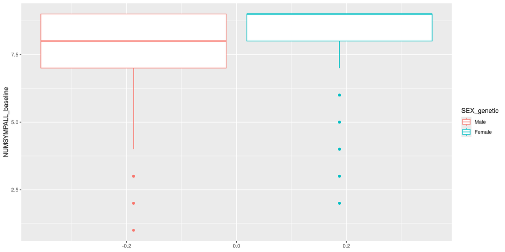

```r
ggplot(df_ND_covid[!is.na(df_ND_covid$NUMSYMPALL_baseline) & !is.na(df_ND_covid$SEX_genetic),],
             aes(y = NUMSYMPALL_baseline, colour = SEX_genetic)) +
  geom_boxplot()
```

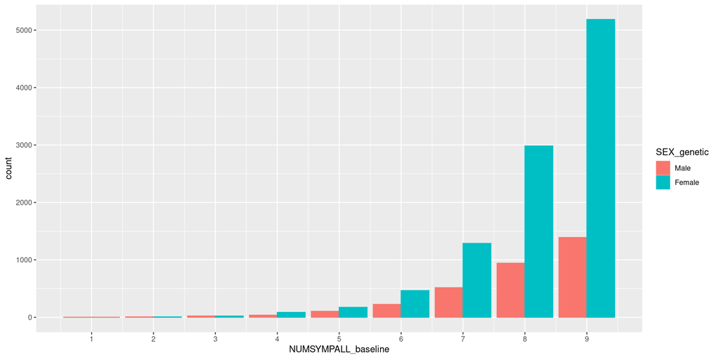

```r
ggplot(df_ND_covid[!is.na(df_ND_covid$NUMSYMPALL_baseline) & !is.na(df_ND_covid$SEX_genetic),],
             aes (x = NUMSYMPALL_baseline, colour = SEX_genetic, fill = SEX_genetic)) +
  geom_bar(position = "dodge") +
  scale_x_continuous(breaks = c(1,2,3,4,5,6,7,8,9))
```

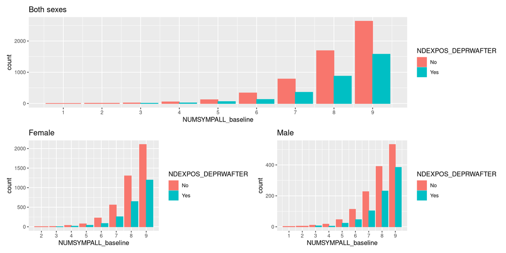

```r
p1 <- ggplot(df_ND_covid[!is.na(df_ND_covid$NUMSYMPALL_baseline) &
                           !is.na(df_ND_covid$SEX_genetic) &
                           !is.na(df_ND_covid$NDEXPOS_DEPRWAFTER), ],
             aes (x = NUMSYMPALL_baseline, colour = NDEXPOS_DEPRWAFTER, fill = NDEXPOS_DEPRWAFTER)) +
  geom_bar(position = "dodge") +
  scale_x_continuous(breaks = c(1,2,3,4,5,6,7,8,9)) +
  ggtitle("Both sexes")

p2 <- ggplot(df_ND_covid[!is.na(df_ND_covid$NUMSYMPALL_baseline) &
                           !is.na(df_ND_covid$SEX_genetic) &
                           (df_ND_covid$SEX_genetic == "Female") &
                           !is.na(df_ND_covid$NDEXPOS_DEPRWAFTER), ],
             aes (x = NUMSYMPALL_baseline, colour = NDEXPOS_DEPRWAFTER, fill = NDEXPOS_DEPRWAFTER)) +
  geom_bar(position = "dodge") +
  scale_x_continuous(breaks = c(1,2,3,4,5,6,7,8,9)) +
  ggtitle("Female")

p3 <- ggplot(df_ND_covid[!is.na(df_ND_covid$NUMSYMPALL_baseline) &
                           !is.na(df_ND_covid$SEX_genetic) &
                           (df_ND_covid$SEX_genetic == "Male") &
                           !is.na(df_ND_covid$NDEXPOS_DEPRWAFTER), ],
             aes (x = NUMSYMPALL_baseline, colour = NDEXPOS_DEPRWAFTER, fill = NDEXPOS_DEPRWAFTER)) +
  geom_bar(position = "dodge") +
  scale_x_continuous(breaks = c(1,2,3,4,5,6,7,8,9)) +
  ggtitle("Male")



p1 / (p2 | p3)
```

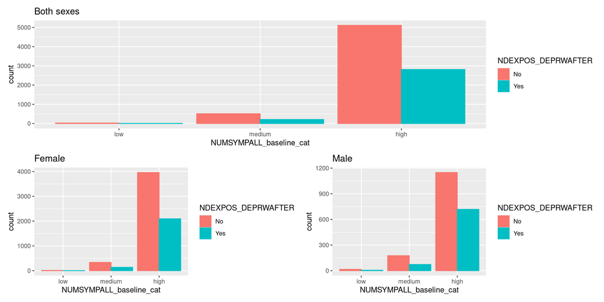

```r
p1 <- ggplot(df_ND_covid[!is.na(df_ND_covid$NUMSYMPALL_baseline_cat) &
                           !is.na(df_ND_covid$SEX_genetic) &
                           !is.na(df_ND_covid$NDEXPOS_DEPRWAFTER), ],
             aes (x = NUMSYMPALL_baseline_cat, colour = NDEXPOS_DEPRWAFTER, fill = NDEXPOS_DEPRWAFTER)) +
  geom_bar(position = "dodge") +
  ggtitle("Both sexes")


p2 <- ggplot(df_ND_covid[!is.na(df_ND_covid$NUMSYMPALL_baseline_cat) &
                           !is.na(df_ND_covid$SEX_genetic) &
                           (df_ND_covid$SEX_genetic == "Female") &
                           !is.na(df_ND_covid$NDEXPOS_DEPRWAFTER), ],
             aes (x = NUMSYMPALL_baseline_cat, colour = NDEXPOS_DEPRWAFTER, fill = NDEXPOS_DEPRWAFTER)) +
  geom_bar(position = "dodge") +
  ggtitle("Female")

p3 <- ggplot(df_ND_covid[!is.na(df_ND_covid$NUMSYMPALL_baseline_cat) &
                           !is.na(df_ND_covid$SEX_genetic) &
                           (df_ND_covid$SEX_genetic == "Male") &
                           !is.na(df_ND_covid$NDEXPOS_DEPRWAFTER), ],
             aes (x = NUMSYMPALL_baseline_cat, colour = NDEXPOS_DEPRWAFTER, fill = NDEXPOS_DEPRWAFTER)) +
  geom_bar(position = "dodge") +
  ggtitle("Male")



p1 / (p2 | p3)
```

### ND experience

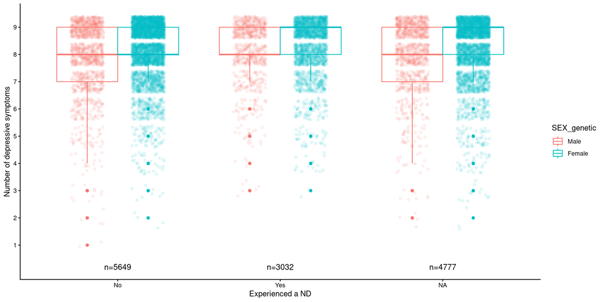

```r
ggplot(df_ND_covid[!is.na(df_ND_covid$SEX_genetic),], aes(x = as.factor(NDEXPOS_DEPRWAFTER), y = NUMSYMPALL_baseline, colour = SEX_genetic)) +
  geom_boxplot(position = position_dodge(width = 0.75)) +
  geom_point(position = position_jitterdodge(dodge.width = 0.75, jitter.width = 0.4, jitter.height = 0.4), alpha = 0.1) +
  stat_n_text() +
  labs(x = "Experienced a ND",
       y = "Number of depressive symptoms") +
  scale_y_continuous(breaks = c(1,2,3,4,5,6,7,8,9)) +
  theme(axis.text.x = element_text(angle = 45, vjust = 1, hjust=1)) +
  theme_classic()
```

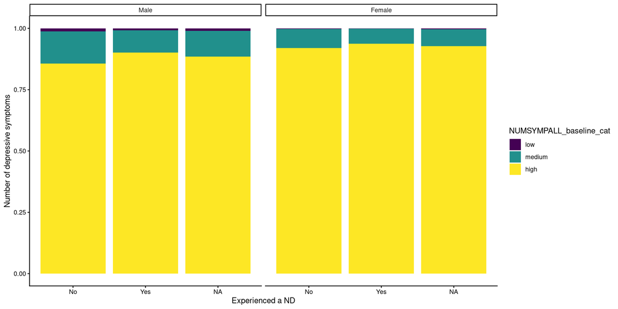

```r
ggplot(df_ND_covid[!is.na(df_ND_covid$SEX_genetic) & !is.na(df_ND_covid$NUMSYMPALL_baseline_cat),], aes(x = as.factor(NDEXPOS_DEPRWAFTER), fill = NUMSYMPALL_baseline_cat)) +
  geom_bar(position = "fill") +
  # stat_n_text() +
  labs(x = "Experienced a ND",
       y = "Number of depressive symptoms") +
  facet_wrap(~ SEX_genetic) +
  theme(axis.text.x = element_text(angle = 45, vjust = 1, hjust=1)) +
  theme_classic()
```

## Fit Models

### Proportional Odds

```r
NDworse_PO <- VGAM::vglm(NUMSYMPALL_baseline_cat ~
                                  PRS_stand_genetic +
                                  NDEXPOS_DEPRWAFTER +
                                  AGE_baseline +
                                  SEX_genetic +
                                  PC1_genetic +
                                  PC2_genetic +
                                  PC3_genetic +
                                  PC4_genetic +
                           PC5_genetic +
                           PC6_genetic +
                           PC7_genetic +
                           PC8_genetic +
                           PC9_genetic +
                           PC10_genetic,
                                family = VGAM::cumulative(logitlink, parallel = T, reverse = T), # with PO (package pammtools masks VGAM cumulative so specify from VGAM)
                                data = df_ND_covid)

NDworse_female_PO <- VGAM::vglm(NUMSYMPALL_baseline_cat ~
                PRS_stand_genetic +
                NDEXPOS_DEPRWAFTER +
                AGE_baseline +
                PC1_genetic +
                PC2_genetic +
                PC3_genetic +
                PC4_genetic +
                  PC5_genetic +
                  PC6_genetic +
                  PC7_genetic +
                  PC8_genetic +
                  PC9_genetic +
                  PC10_genetic,
              family = VGAM::cumulative(logitlink, parallel = T, reverse = T), # with PO (package pammtools masks VGAM cumulative so specify from VGAM)
              data = df_ND_covid[df_ND_covid$SEX_genetic == "Female", ])

NDworse_male_PO <- VGAM::vglm(NUMSYMPALL_baseline_cat ~
                               PRS_stand_genetic +
                               NDEXPOS_DEPRWAFTER +
                               AGE_baseline +
                               PC1_genetic +
                               PC2_genetic +
                               PC3_genetic +
                               PC4_genetic +
                                PC5_genetic +
                                PC6_genetic +
                                PC7_genetic +
                                PC8_genetic +
                                PC9_genetic +
                                PC10_genetic,
                             family = VGAM::cumulative(logitlink, parallel = T, reverse = T), # with PO (package pammtools masks VGAM cumulative so specify from VGAM)
                             data = df_ND_covid[df_ND_covid$SEX_genetic == "Male", ])
```

### Partial Proportional Odds

```r
NDworse_PartPO_NDexpos <- VGAM::vglm(NUMSYMPALL_baseline_cat ~
                                              PRS_stand_genetic +
                                              NDEXPOS_DEPRWAFTER +
                                              AGE_baseline +
                                              SEX_genetic +
                                              PC1_genetic +
                                              PC2_genetic +
                                              PC3_genetic +
                                              PC4_genetic +
                                       PC5_genetic +
                                       PC6_genetic +
                                       PC7_genetic +
                                       PC8_genetic +
                                       PC9_genetic +
                                       PC10_genetic,
                                            family = VGAM::cumulative(logitlink, parallel = F ~ NDEXPOS_DEPRWAFTER, reverse = T), # with PO (package pammtools masks VGAM cumulative so specify from VGAM)
                                            data = df_ND_covid)

NDworse_PartPO_PRS <- VGAM::vglm(NUMSYMPALL_baseline_cat ~
                                          PRS_stand_genetic +
                                          NDEXPOS_DEPRWAFTER +
                                          AGE_baseline +
                                          SEX_genetic +
                                          PC1_genetic +
                                          PC2_genetic +
                                          PC3_genetic +
                                          PC4_genetic +
                                   PC5_genetic +
                                   PC6_genetic +
                                   PC7_genetic +
                                   PC8_genetic +
                                   PC9_genetic +
                                   PC10_genetic,
                                        family = VGAM::cumulative(logitlink, parallel = F ~ PRS_stand_genetic, reverse = T), # with PO (package pammtools masks VGAM cumulative so specify from VGAM)
                                        data = df_ND_covid)

NDworse_PartPO_NDexpos_PRS <- VGAM::vglm(NUMSYMPALL_baseline_cat ~
                                                  PRS_stand_genetic +
                                                  NDEXPOS_DEPRWAFTER +
                                                  AGE_baseline +
                                                  SEX_genetic +
                                                  PC1_genetic +
                                                  PC2_genetic +
                                                  PC3_genetic +
                                                  PC4_genetic +
                                           PC5_genetic +
                                           PC6_genetic +
                                           PC7_genetic +
                                           PC8_genetic +
                                           PC9_genetic +
                                           PC10_genetic,
                                                family = VGAM::cumulative(logitlink, parallel = F ~ NDEXPOS_DEPRWAFTER + PRS_stand_genetic, reverse = T), # with PO (package pammtools masks VGAM cumulative so specify from VGAM)
                                                data = df_ND_covid)

NDworse_female_PartPO_NDexpos <- VGAM::vglm(NUMSYMPALL_baseline_cat ~
                                            PRS_stand_genetic +
                                            NDEXPOS_DEPRWAFTER +
                                            AGE_baseline +
                                            PC1_genetic +
                                            PC2_genetic +
                                            PC3_genetic +
                                            PC4_genetic +
                                              PC5_genetic +
                                              PC6_genetic +
                                              PC7_genetic +
                                              PC8_genetic +
                                              PC9_genetic +
                                              PC10_genetic,
                                          family = VGAM::cumulative(logitlink, parallel = F ~ NDEXPOS_DEPRWAFTER, reverse = T), # with PO (package pammtools masks VGAM cumulative so specify from VGAM)
                                          data = df_ND_covid[df_ND_covid$SEX_genetic == "Female", ])

NDworse_female_PartPO_PRS <- VGAM::vglm(NUMSYMPALL_baseline_cat ~
                                        PRS_stand_genetic +
                                        NDEXPOS_DEPRWAFTER +
                                        AGE_baseline +
                                        PC1_genetic +
                                        PC2_genetic +
                                        PC3_genetic +
                                        PC4_genetic +
                                          PC5_genetic +
                                          PC6_genetic +
                                          PC7_genetic +
                                          PC8_genetic +
                                          PC9_genetic +
                                          PC10_genetic,
                                      family = VGAM::cumulative(logitlink, parallel = F ~ PRS_stand_genetic, reverse = T), # with PO (package pammtools masks VGAM cumulative so specify from VGAM)
                                      data = df_ND_covid[df_ND_covid$SEX_genetic == "Female", ])

NDworse_female_PartPO_NDexpos_PRS <- VGAM::vglm(NUMSYMPALL_baseline_cat ~
                                                PRS_stand_genetic +
                                                NDEXPOS_DEPRWAFTER +
                                                AGE_baseline +
                                                PC1_genetic +
                                                PC2_genetic +
                                                PC3_genetic +
                                                PC4_genetic +
                                                  PC5_genetic +
                                                  PC6_genetic +
                                                  PC7_genetic +
                                                  PC8_genetic +
                                                  PC9_genetic +
                                                  PC10_genetic,
                                              family = VGAM::cumulative(logitlink, parallel = F ~ NDEXPOS_DEPRWAFTER + PRS_stand_genetic, reverse = T), # with PO (package pammtools masks VGAM cumulative so specify from VGAM)
                                              data = df_ND_covid[df_ND_covid$SEX_genetic == "Female", ])

NDworse_male_PartPO_NDexpos <- VGAM::vglm(NUMSYMPALL_baseline_cat ~
                                PRS_stand_genetic +
                                NDEXPOS_DEPRWAFTER +
                                AGE_baseline +
                                PC1_genetic +
                                PC2_genetic +
                                PC3_genetic +
                                PC4_genetic +
                                  PC5_genetic +
                                  PC6_genetic +
                                  PC7_genetic +
                                  PC8_genetic +
                                  PC9_genetic +
                                  PC10_genetic,
                              family = VGAM::cumulative(logitlink, parallel = F ~ NDEXPOS_DEPRWAFTER, reverse = T), # with PO (package pammtools masks VGAM cumulative so specify from VGAM)
                              data = df_ND_covid[df_ND_covid$SEX_genetic == "Male", ])

NDworse_male_PartPO_PRS <- VGAM::vglm(NUMSYMPALL_baseline_cat ~
                                            PRS_stand_genetic +
                                            NDEXPOS_DEPRWAFTER +
                                            AGE_baseline +
                                            PC1_genetic +
                                            PC2_genetic +
                                            PC3_genetic +
                                            PC4_genetic +
                                        PC5_genetic +
                                        PC6_genetic +
                                        PC7_genetic +
                                        PC8_genetic +
                                        PC9_genetic +
                                        PC10_genetic,
                                          family = VGAM::cumulative(logitlink, parallel = F ~ PRS_stand_genetic, reverse = T), # with PO (package pammtools masks VGAM cumulative so specify from VGAM)
                                          data = df_ND_covid[df_ND_covid$SEX_genetic == "Male", ])

NDworse_male_PartPO_NDexpos_PRS <- VGAM::vglm(NUMSYMPALL_baseline_cat ~
                                            PRS_stand_genetic +
                                            NDEXPOS_DEPRWAFTER +
                                            AGE_baseline +
                                            PC1_genetic +
                                            PC2_genetic +
                                            PC3_genetic +
                                            PC4_genetic +
                                              PC5_genetic +
                                              PC6_genetic +
                                              PC7_genetic +
                                              PC8_genetic +
                                              PC9_genetic +
                                              PC10_genetic,
                                          family = VGAM::cumulative(logitlink, parallel = F ~ NDEXPOS_DEPRWAFTER + PRS_stand_genetic, reverse = T), # with PO (package pammtools masks VGAM cumulative so specify from VGAM)
                                          data = df_ND_covid[df_ND_covid$SEX_genetic == "Male", ])
```

## Check Models

### Proportional Odds

#### Both sexes

```r
### Test goodness of fit ###

# lipsitz test
lipsitz(NDworse_PO)
```

```
##
## Lipsitz Test:
##
##                       LR   df   pr(>chi)
## ordinal(lipsitz)  3.2187    9      0.955
##
## H0: No lack of fit dictated
```

```r
# pulkstenis-robinson test
# (requires the vector of categorical input variables as an argument)
pulkroben(NDworse_PO, test = c("chisq","deviance"), tables = FALSE)
```

```
##
## Pulkstenis-Robinson Chi-squared Test:
##
##                     chi-sq   df   pr(>chi)
## ordinal(pulkroben)  22.961   11     0.0179 *
## ---
## Signif. codes:  0 '***' 0.001 '**' 0.01 '*' 0.05 '.' 0.1 ' ' 1
##
## H0: No lack of fit dictated
##
## rho: 100%
```

```r
# Hosmer-Lemeshow test
hosmerlem(NDworse_PO)
```

```
##
## Hosmer-Lemeshow Test:
##
##                     Chi-sq  df  pr(>chi)
## ordinal(Hosmerlem)  21.719  17    0.1958
##
## H0: No lack of fit dictated
##
## rho: 100%
```

```r
### Test proportional odds assumption ###

# Brant Wald Test
# A generalized ordinal logistic regression model is approximated and compared to the calculated proportional odds model (a generalized ordinal logistic regression model is simply a relaxing of the proportional odds model to allow for different coefficients at each level of the ordinal outcome variable.)
# A Wald test is a hypothesis test of the significance of the difference in model coefficients, producing a chi-square statistic. A low p-value in a Brant-Wald test is an indicator that the coefficient does not satisfy the proportional odds assumption.
# A p-value of less than 0.05 on this test, particularly on the Omnibus plus at least one of the variables should be interpreted as a failure of the proportional odds assumption.

brant.test(NDworse_PO)
```

```
##
## Brant Test:
##                          chi-sq   df   pr(>chi)
## Omnibus                  29.095   14      0.010 *
## PRS_stand_genetic         0.058    1      0.809
## NDEXPOS_DEPRWAFTERYes     0.600    1      0.439
## AGE_baseline              4.957    1      0.026 *
## SEX_geneticFemale         6.593    1      0.010 *
## PC1_genetic               1.713    1      0.191
## PC2_genetic               0.003    1      0.955
## PC3_genetic               0.081    1      0.776
## PC4_genetic               0.432    1      0.511
## PC5_genetic               3.662    1      0.056 .
## PC6_genetic               3.111    1      0.078 .
## PC7_genetic               0.000    1      0.991
## PC8_genetic               0.250    1      0.617
## PC9_genetic               0.253    1      0.615
## PC10_genetic              2.467    1      0.116
## ---
## Signif. codes:  0 '***' 0.001 '**' 0.01 '*' 0.05 '.' 0.1 ' ' 1
##
## H0: Proportional odds assumption holds
```

```r
# Sighting coefficients of stratified binomial models - want each to be similar
# create binary variables for every combo of the 3 categories
x <- df_ND_covid %>%
  mutate(SYMPlowplus = case_when(
    NUMSYMPALL_baseline_cat == 'low' ~ 0,
    NUMSYMPALL_baseline_cat == 'medium' |  NUMSYMPALL_baseline_cat == 'high' ~ 1),
    SYMPmedplus = case_when(
      NUMSYMPALL_baseline_cat == 'low' | NUMSYMPALL_baseline_cat == 'medium' ~ 0,
      NUMSYMPALL_baseline_cat == 'high' ~ 1)
  )


# Create logistic regression for each
lowplus_model <- glm(SYMPlowplus ~
                       PRS_stand_genetic +
                       NDEXPOS_DEPRWAFTER +
                       AGE_baseline +
                       SEX_genetic +
                       PC1_genetic +
                       PC2_genetic +
                       PC3_genetic +
                       PC4_genetic +
                       PC5_genetic +
                       PC6_genetic +
                       PC7_genetic +
                       PC8_genetic +
                       PC9_genetic +
                       PC10_genetic,
                     family = binomial(link = 'logit'),
                     data = x)

medplus_model <- glm(SYMPmedplus ~
                       PRS_stand_genetic +
                       NDEXPOS_DEPRWAFTER +
                       AGE_baseline +
                       SEX_genetic +
                       PC1_genetic +
                       PC2_genetic +
                       PC3_genetic +
                       PC4_genetic +
                       PC5_genetic +
                       PC6_genetic +
                       PC7_genetic +
                       PC8_genetic +
                       PC9_genetic +
                       PC10_genetic,
                     family = binomial(link = 'logit'),
                     data = x)


# display the coefficients of all models and examine the difference between them.
# coefficients (i.e. the slopes) should be similar for all models to hold the proportional odds assumption

# table
coeffs <- data.frame(
  'ordinal' = coef(NDworse_PO)[-c(1,2)],
  'binary low vs med and high' = lowplus_model$coefficients[-1],
  'binary low and med vs high' = medplus_model$coefficients[-1])

coeffs %>%
  kable()
```

|  | ordinal | binary.low.vs.med.and.high | binary.low.and.med.vs.high |
| --- | --- | --- | --- |
| PRS_stand_genetic | 0.1526470 | 0.1918262 | 0.1523522 |
| NDEXPOS_DEPRWAFTERYes | 0.3385452 | 0.6450856 | 0.3359658 |
| AGE_baseline | -0.0331560 | -0.0615749 | -0.0329527 |
| SEX_geneticFemale | 0.3981638 | 1.2739559 | 0.3892833 |
| PC1_genetic | 42.4749692 | -437.9669019 | 45.2157527 |
| PC2_genetic | -56.5503507 | -67.1031129 | -57.6277343 |
| PC3_genetic | -12.5820344 | 21.7719196 | -12.7665110 |
| PC4_genetic | 9.5302813 | 84.7849485 | 8.8787047 |
| PC5_genetic | 9.6120894 | 121.1217845 | 8.7887526 |
| PC6_genetic | 3.2734085 | 50.4861933 | 2.7560833 |
| PC7_genetic | 11.1182081 | 12.0513113 | 11.4003029 |
| PC8_genetic | -22.7564556 | 0.5751124 | -23.1012891 |
| PC9_genetic | -12.0902406 | -31.5773344 | -11.7830164 |
| PC10_genetic | -11.1243183 | 50.4702434 | -11.5156211 |

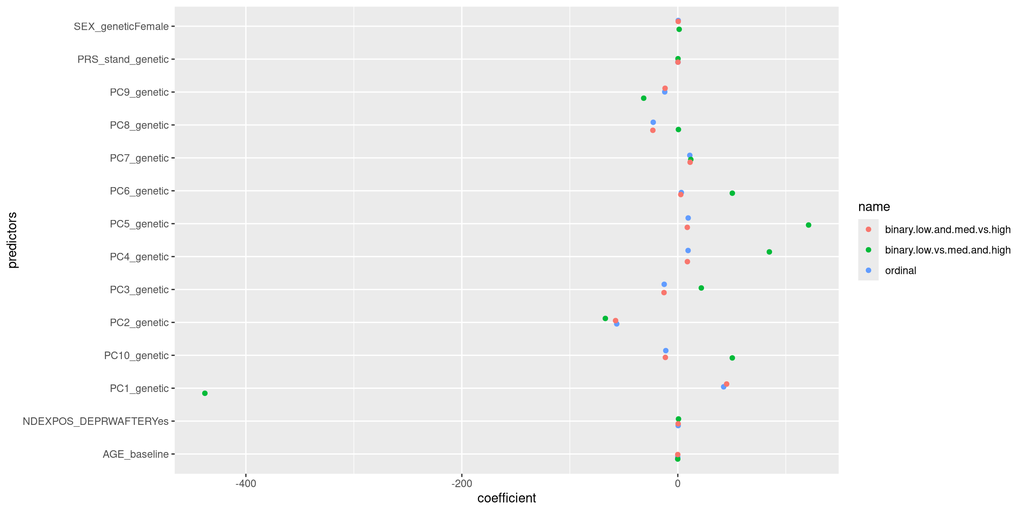

```r
coeffs2 <- coeffs %>%
  rownames_to_column() %>%
  pivot_longer(cols = 2:4)

ggplot(coeffs2, aes(x = value, y = rowname, group = name, colour = name)) +
  geom_jitter(height = 0.2) +
  labs(x = "coefficient", y = "predictors")
```

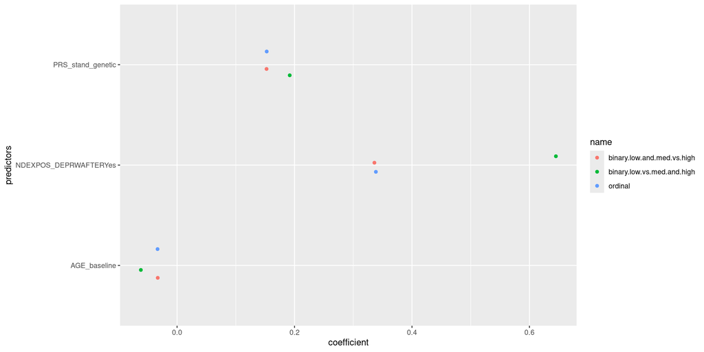

```r
coeffs3 <- coeffs2 %>%
  filter(rowname == 'PRS_stand_genetic' | rowname == 'NDEXPOS_DEPRWAFTERYes' | rowname == "AGE_baseline")

ggplot(coeffs3, aes(x = value, y = rowname, group = name, colour = name)) +
  geom_jitter(height = 0.2) +
  labs(x = "coefficient", y = "predictors")
```